# Lab 2

Aleah Querns

2/3/2022

**Load libraries:**

```r
library(gapminder)
library(tidyverse)
library(datasets)
library(viridis)
library(gridExtra)
```

## Question 1:

For the gapminder data order countries in reverse alphabetical order, then display the first 15.

```r
data(gapminder)

gapminder %>%
  arrange(., desc(country)) %>%
  head(., 15)
```

```
## # A tibble: 15 x 6
##    country  continent  year lifeExp      pop gdpPercap
##    <fct>    <fct>     <int>   <dbl>    <int>     <dbl>
##  1 Zimbabwe Africa     1952    48.5  3080907      407.
##  2 Zimbabwe Africa     1957    50.5  3646340      519.
##  3 Zimbabwe Africa     1962    52.4  4277736      527.
##  4 Zimbabwe Africa     1967    54.0  4995432      570.
##  5 Zimbabwe Africa     1972    55.6  5861135      799.
##  6 Zimbabwe Africa     1977    57.7  6642107      686.
##  7 Zimbabwe Africa     1982    60.4  7636524      789.
##  8 Zimbabwe Africa     1987    62.4  9216418      706.
##  9 Zimbabwe Africa     1992    60.4 10704340      693.
## 10 Zimbabwe Africa     1997    46.8 11404948      792.
## 11 Zimbabwe Africa     2002    40.0 11926563      672.
## 12 Zimbabwe Africa     2007    43.5 12311143      470.
## 13 Zambia   Africa     1952    42.0  2672000     1147.
## 14 Zambia   Africa     1957    44.1  3016000     1312.
## 15 Zambia   Africa     1962    46.0  3421000     1453.
```

**Potential issues with this process that might lead to ordering problems in a different dataset: If the chosen category wasn’t listed as a factor with levels (and perhaps were a a logical statement or complex number instead) then there would probably be issues with ordering, since R wouldn’t always know what order to put stuff in**

## Question 2:

Calculate and display the mean, median, and standard deviation for the Life expectancy, Population, and GDPperCapita in the gapminder dataset.

```r
#Life expectancy


LifeExpectancy<- gapminder%>%
  summarize(mean_life= mean(gapminder$lifeExp),
          median_life= median(gapminder$lifeExp),
          sd_life = sd(gapminder$lifeExp))

#Population

Population<- gapminder%>%
  summarize(mean_pop = mean(gapminder$pop),
          median_pop= median(gapminder$pop),
          sd_pop = sd(gapminder$pop))

#GDPperCapita

GDPperCap<- gapminder%>%
  summarize(mean_gdp = mean(gapminder$gdpPercap),
          median_gdp = median(gapminder$gdpPercap),
          sd_gdp = sd(gapminder$gdpPercap))

LifeExpectancy
```

```
## # A tibble: 1 x 3
##   mean_life median_life sd_life
##       <dbl>       <dbl>   <dbl>
## 1      59.5        60.7    12.9
```

```r
Population
```

```
## # A tibble: 1 x 3
##    mean_pop median_pop     sd_pop
##       <dbl>      <dbl>      <dbl>
## 1 29601212.   7023596. 106157897.
```

```r
GDPperCap
```

```
## # A tibble: 1 x 3
##   mean_gdp median_gdp sd_gdp
##      <dbl>      <dbl>  <dbl>
## 1    7215.      3532.  9857.
```

## Question 3:

Calculate and display in a single dataframe the mean values for Life expectancy, Population, and GDPperCapita for each continent.

```r
mean_bycontinent<- gapminder %>%
  group_by(continent)%>%
  summarize(mean_life = mean(lifeExp),
            mean_pop = mean(pop),
            mean_gdp = mean(gdpPercap))

mean_bycontinent
```

```
## # A tibble: 5 x 4
##   continent mean_life  mean_pop mean_gdp
##   <fct>         <dbl>     <dbl>    <dbl>
## 1 Africa         48.9  9916003.    2194.
## 2 Americas       64.7 24504795.    7136.
## 3 Asia           60.1 77038722.    7902.
## 4 Europe         71.9 17169765.   14469.
## 5 Oceania        74.3  8874672.   18622.
```

## Question 4:

Create a scatter plot of the global average Life expectancy over time and display the first 5 records for the dataset used to build this plot. Customize the display of the plot to make it less *blah*.

```r
avelife <- gapminder %>%
  group_by(year) %>%
  summarize(GlobalAvgLifeExpectancy = mean (lifeExp))

head(avelife, 5)
```

```
## # A tibble: 5 x 2
##    year GlobalAvgLifeExpectancy
##   <int>                   <dbl>
## 1  1952                    49.1
## 2  1957                    51.5
## 3  1962                    53.6
## 4  1967                    55.7
## 5  1972                    57.6
```

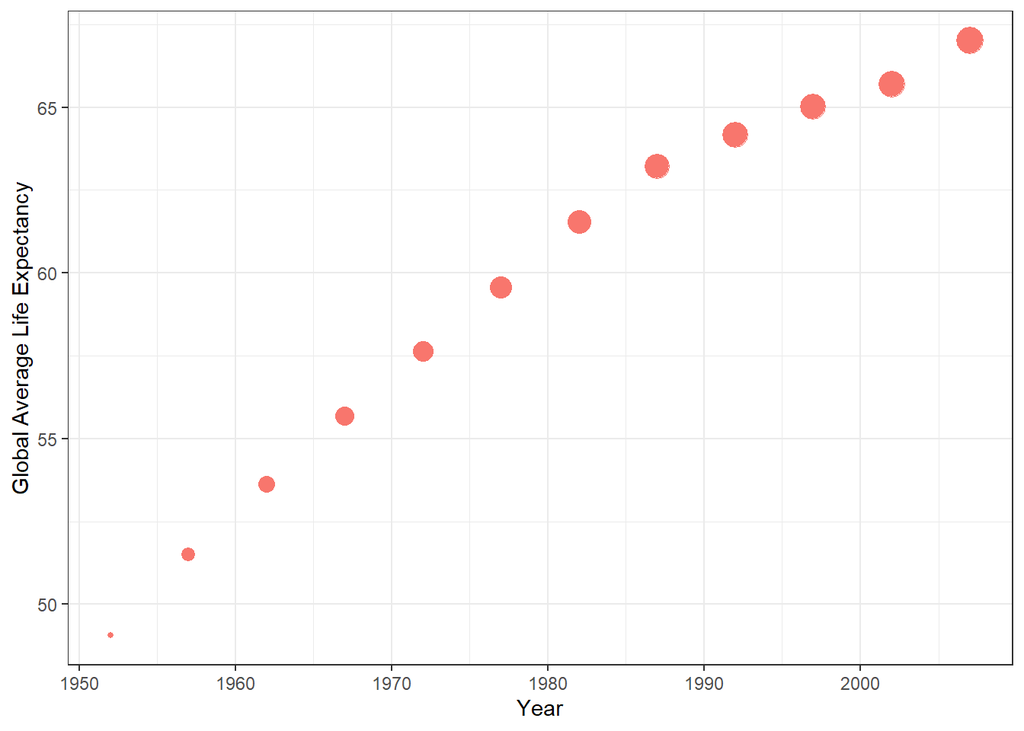

```r
ggplot(avelife, aes(x=year, y=GlobalAvgLifeExpectancy)) +
  geom_point(aes(col="cyan4", size=GlobalAvgLifeExpectancy)) +
  xlab("Year") +
  ylab("Global Average Life Expectancy") +
  theme_bw()+
  theme(legend.position = "none")
```

## Question 5:

Pull in a dataset of your choice from the datasets package that has a dataframe structure. Then examine the structure of the data including: class types, header information, and dimensions.

**Here, I used the beavers dataset (specifically beaver1)**

```r
data(beavers) #focusing on beaver 1

str(beaver1)
```

```
## 'data.frame':    114 obs. of  4 variables:
##  $ day  : num  346 346 346 346 346 346 346 346 346 346 ...
##  $ time : num  840 850 900 910 920 930 940 950 1000 1010 ...
##  $ temp : num  36.3 36.3 36.4 36.4 36.5 ...
##  $ activ: num  0 0 0 0 0 0 0 0 0 0 ...
```

## Question 6:

Calculate general summary statistics for the dataset.

```r
beaver1_summary<-
  beaver1 %>%
  summarize(., ave_temp = mean(temp),
            sd_temp= sd(temp),
            times_active = sum(activ),
            num_obs = length(time))

beaver1_summary
```

```
##   ave_temp   sd_temp times_active num_obs
## 1 36.86219 0.1934217            6     114
```

## Question 7:

Calculate summary statistics for groups/subsets of the dataset (these groupings could be based on time period, species, location, etc…).

```r
beaver1_summary_byday<-
  beaver1 %>%
  group_by(day)%>%
  summarize(., ave_temp = mean(temp),
            sd_temp = sd(temp),
            times_active = sum(activ),
            num_obs = length(time))

beaver1_summary_byday
```

```
## # A tibble: 2 x 5
##     day ave_temp sd_temp times_active num_obs
##   <dbl>    <dbl>   <dbl>        <dbl>   <int>
## 1   346     36.9   0.210            5      91
## 2   347     36.8   0.104            1      23
```

## Question 8:

Create 2 plots of your choice, one showing grouped data and the other showing ungrouped data. Give each plot a title and descriptive x and y axis labels. Customize at least one graphic option (color, point type, line width, etc…) on these plots.

**Wasn’t really sure how to graph the previously described summary statistics in a way that would be meaningful, so instead I made a histogram (ungrouped) and time series/line graph (grouped by day)**

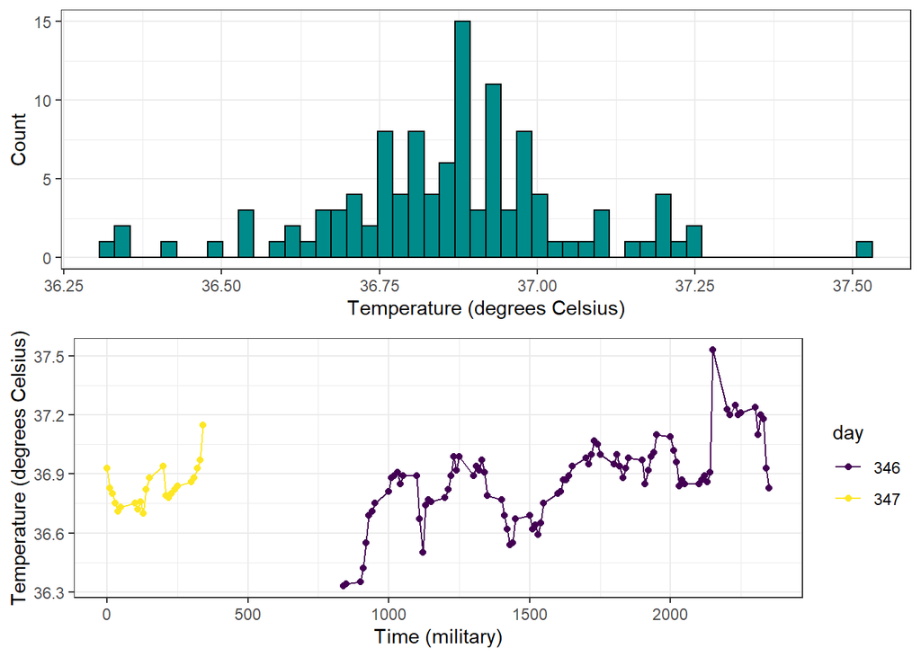

```r
beaver1$day <- as.character(beaver1$day)

 p1<-ggplot(data=beaver1, aes(temp)) +
    geom_histogram(fill="cyan4", col="black", bins=50)+
   xlab("Temperature (degrees Celsius)") +
   ylab("Count")+
   theme_bw()
  #ungrouped histogram

 p2<-ggplot(data=beaver1, aes(x=time, y=temp))+
   geom_line(aes(group=day, col=day))+
   geom_point(aes(group=day, col=day))+
   xlab("Time (military)")+
   ylab("Temperature (degrees Celsius)") +
   theme_bw() +
   scale_color_viridis(discrete=TRUE, option = "D")

 grid.arrange(p1,p2)
```